# 重賞レース予測レポート【レース終了】

作成日時: 2026/01/18 16:52:35

☞ [マニュアル(pdf)](https://ryutoro-galois.github.io/keiba-predictor/manual/manual.pdf)

☞ 過去6年の同一レース結果: [2025年](https://ryutoro-galois.github.io/keiba-predictor/report/PredResult_2025y_raceDate_20250119_20250119.html), [2024年](https://ryutoro-galois.github.io/keiba-predictor/report/PredResult_2024y_raceDate_20240121_20240121.html), [2023年](https://ryutoro-galois.github.io/keiba-predictor/report/PredResult_2023y_raceDate_20230114_20230115.html), [2022年](https://ryutoro-galois.github.io/keiba-predictor/report/PredResult_2022y_raceDate_20220115_20220116.html), [2021年](https://ryutoro-galois.github.io/keiba-predictor/report/PredResult_2021y_raceDate_20210116_20210117.html), [2020年](https://ryutoro-galois.github.io/keiba-predictor/report/PredResult_2020y_raceDate_20200118_20200119.html)

☞ 過去4週間の別レース結果: [1週前(1/11-12)](https://ryutoro-galois.github.io/keiba-predictor/report/PredResult_2026y_raceDate_20260111_20260112.html), [2週前(1/4)](https://ryutoro-galois.github.io/keiba-predictor/report/PredResult_2026y_raceDate_20260104_20260104.html), [3週前(12/27-28)](https://ryutoro-galois.github.io/keiba-predictor/report/PredResult_2025y_raceDate_20251227_20251228.html), [4週前(12/20-21)](https://ryutoro-galois.github.io/keiba-predictor/report/PredResult_2025y_raceDate_20251220_20251221.html)

☞ netkeiba: [京成杯(GⅢ)](https://race.netkeiba.com/race/result.html?race_id=202606010711&rf=race_submenu), [日経新春杯(GⅡ)](https://race.netkeiba.com/race/result.html?race_id=202608010711&rf=race_submenu)

☞ レース結果(csv): [1/17-18](https://ryutoro-galois.github.io/keiba-predictor/csv/race_result_20260117_20260118.csv)

## 【レース結果(1)】人気と着順の関係

### 【京成杯(2026/01/18(日))】

【京成杯(GⅢ)】  
2026/01/18(日), 06_中山, 芝右2000m

[interactive chart not shown]

### 【日経新春杯(2026/01/18(日))】

【日経新春杯(GⅡ)】  
2026/01/18(日), 08_京都, 芝右外2400m

[interactive chart not shown]

## 【レース結果(2)】コーナー通過順位

### 【京成杯(2026/01/18(日))】

【京成杯(GⅢ)】  
2026/01/18(日), 06_中山, 芝右2000m

[interactive chart not shown]

### 【日経新春杯(2026/01/18(日))】

【日経新春杯(GⅡ)】  
2026/01/18(日), 08_京都, 芝右外2400m

[interactive chart not shown]

## 0. 推し馬予測 (AI予測)

### 【京成杯(GⅢ) 2026/01/18(日)】

- 本命(◎): 1-3着内確率(勝負強さ)が1位の馬
- 対抗(◯): 1-3着内確率が2-N位(20%程度以上)の中で予測タイムが最も速い馬
- 3番手(▲): 1-3着内確率が2-N位(20%程度以上)のでダークホース確率が最も高い馬
- 穴: ダークホース確率が上位1-M位(40%程度以上)の中で1-3着内確率が最も高い馬

| 推し馬 | 枠番 | 馬番 | 人気 | オッズ | 馬名 | 騎手 | 調教師 | 予測タイム(sec) | 1_順位 | 1-3着内確率(%) | 2_順位 | ﾀﾞｰｸﾎｰｽ確率(%) | 3_順位 |
| --- | --- | --- | --- | --- | --- | --- | --- | --- | --- | --- | --- | --- | --- |
| 本命(◎) | 8 | 15 | 2 | 5.2 | アクセス | 北村友一 | 上村洋行 | 128.7 | 8.0 | 19.6 | 1 | 1.0 | 13 |
| 対抗(◯) | 7 | 12 | 1 | 3.7 | ソラネルマン | Ｃ．ルメール | 手塚貴久 | 120.6 | 1.5 | 16.8 | 2 | 1.1 | 12 |
| 3番手(▲) | 1 | 1 | 12 | 39.4 | ブラックハヤテ | 丹内祐次 | 蛯名利弘 | 128.0 | 5.0 | 8.7 | 6 | 49.8 | 3 |
| 穴 | 3 | 5 | 10 | 28.9 | ショウグンマサムネ | 荻野極 | 佐藤悠太 | 128.0 | 6.0 | 6.9 | 10 | 46.7 | 4 |

### 【日経新春杯(GⅡ) 2026/01/18(日)】

- 本命(◎): 1-3着内確率(勝負強さ)が1位の馬
- 対抗(◯): 1-3着内確率が2-N位(20%程度以上)の中で予測タイムが最も速い馬
- 3番手(▲): 1-3着内確率が2-N位(20%程度以上)のでダークホース確率が最も高い馬
- 穴: ダークホース確率が上位1-M位(40%程度以上)の中で1-3着内確率が最も高い馬

| 推し馬 | 枠番 | 馬番 | 人気 | オッズ | 馬名 | 騎手 | 調教師 | 予測タイム(sec) | 1_順位 | 1-3着内確率(%) | 2_順位 | ﾀﾞｰｸﾎｰｽ確率(%) | 3_順位 |
| --- | --- | --- | --- | --- | --- | --- | --- | --- | --- | --- | --- | --- | --- |
| 本命(◎) | 8 | 12 | 5 | 9.5 | ライラック | 藤岡佑介 | 相沢郁 | 148.8 | 4 | 31.6 | 1 | 1.4 | 9 |
| 対抗(◯) | 5 | 6 | 1 | 2.7 | ゲルチュタール | 坂井瑠星 | 杉山晴紀 | 143.7 | 1 | 20.3 | 5 | 0.4 | 13 |
| 3番手(▲) | 4 | 4 | 7 | 16.0 | オールナット | 西村淳也 | 高野友和 | 146.5 | 2 | 26.2 | 2 | 1.8 | 7 |
| 穴 | 5 | 7 | 9 | 18.8 | ファミリータイム | 松山弘平 | 石坂公一 | 154.9 | 9 | 18.6 | 6 | 43.7 | 5 |

## 1. 予測チャート (タイム/勝負強さ)

### 【京成杯(GⅢ)】

2026/01/18(日), 06_中山, 芝右2000m

[interactive chart not shown]

### 【日経新春杯(GⅡ)】

2026/01/18(日), 08_京都, 芝右外2400m

[interactive chart not shown]

## 2. オッズモニタリング (毎時)

### 【京成杯】

[interactive chart not shown]

### 【日経新春杯】

[interactive chart not shown]

## 3. 出馬表

### 【京成杯 2026/01/18(日) 】

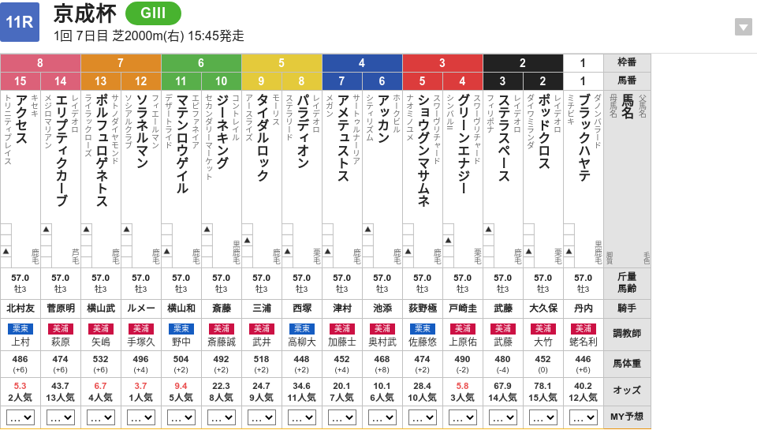

### 【日経新春杯 2026/01/18(日) 】

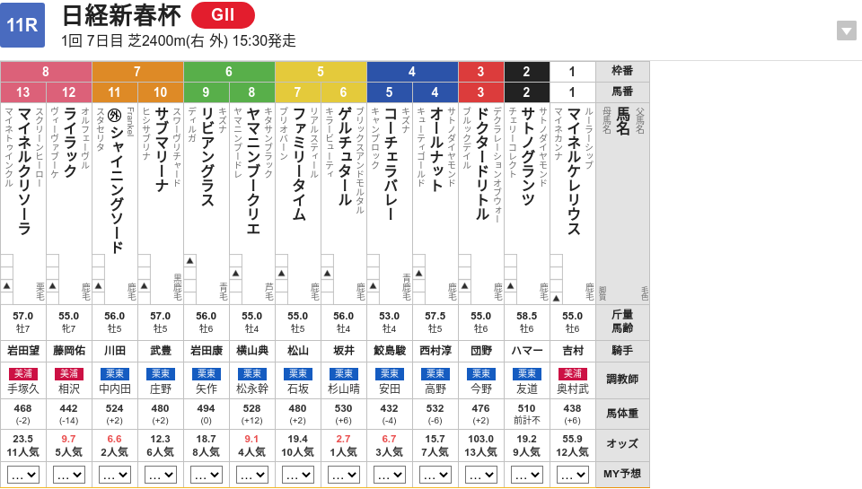

## 4. 単勝予測結果

### 【京成杯(GⅢ) 2026/01/18(日)】

| 枠番 | 馬番 | 人気 | オッズ | 馬名 | 騎手 | 調教師 | 予測タイム(sec) | 1_順位 | 1-3着内確率(%) | 2_順位 | ﾀﾞｰｸﾎｰｽ確率(%) | 3_順位 |
| --- | --- | --- | --- | --- | --- | --- | --- | --- | --- | --- | --- | --- |
| 1 | 1 | 12 | 39.4 | ブラックハヤテ | 丹内祐次 | 蛯名利弘 | 128.0 | 5.0 | 8.7 | 6 | 49.8 | 3 |
| 2 | 2 | 15 | 76.5 | ポッドクロス | 大久保友雅 | 大竹正博 | 130.5 | 11.0 | 5.7 | 12 | 54.4 | 1 |
| 2 | 3 | 14 | 67.3 | ステラスペース | 武藤雅 | 武藤善則 | 134.1 | 15.0 | 3.3 | 15 | 23.4 | 6 |
| 3 | 4 | 3 | 5.9 | グリーンエナジー | 戸崎圭太 | 上原佑紀 | 131.6 | 13.0 | 16.7 | 3 | 0.6 | 15 |
| 3 | 5 | 10 | 28.9 | ショウグンマサムネ | 荻野極 | 佐藤悠太 | 128.0 | 6.0 | 6.9 | 10 | 46.7 | 4 |
| 4 | 6 | 6 | 10.1 | アッカン | 池添謙一 | 奥村武 | 131.7 | 14.0 | 7.8 | 8 | 1.9 | 9 |
| 4 | 7 | 7 | 20.6 | アメテュストス | 津村明秀 | 加藤士津八 | 131.2 | 12.0 | 4.0 | 14 | 1.7 | 10 |
| 5 | 8 | 11 | 34.0 | パラディオン | 西塚洸二 | 高柳大輔 | 128.6 | 7.0 | 6.9 | 11 | 50.4 | 2 |
| 5 | 9 | 9 | 24.4 | タイダルロック | 三浦皇成 | 武井亮 | 129.7 | 9.0 | 4.8 | 13 | 13.5 | 7 |
| 6 | 10 | 8 | 21.6 | ジーネキング | 斎藤新 | 斎藤誠 | 127.6 | 4.0 | 7.7 | 9 | 2.1 | 8 |

[output cut: 5 more lines]

### 【日経新春杯(GⅡ) 2026/01/18(日)】

| 枠番 | 馬番 | 人気 | オッズ | 馬名 | 騎手 | 調教師 | 予測タイム(sec) | 1_順位 | 1-3着内確率(%) | 2_順位 | ﾀﾞｰｸﾎｰｽ確率(%) | 3_順位 |
| --- | --- | --- | --- | --- | --- | --- | --- | --- | --- | --- | --- | --- |
| 1 | 1 | 12 | 55.2 | マイネルケレリウス | 吉村誠之助 | 奥村武 | 154.7 | 6.0 | 8.6 | 11 | 64.8 | 2 |
| 2 | 2 | 10 | 19.6 | サトノグランツ | Ｔ．ハマーハンセン | 友道康夫 | 147.3 | 3.0 | 9.0 | 10 | 37.8 | 6 |
| 3 | 3 | 13 | 102.5 | ドクタードリトル | 団野大成 | 今野貞一 | 155.2 | 10.5 | 5.2 | 12 | 61.7 | 3 |
| 4 | 4 | 7 | 16.0 | オールナット | 西村淳也 | 高野友和 | 146.5 | 2.0 | 26.2 | 2 | 1.8 | 7 |
| 4 | 5 | 2 | 6.7 | コーチェラバレー | 鮫島克駿 | 安田翔伍 | 152.9 | 5.0 | 24.7 | 3 | 1.1 | 12 |
| 5 | 6 | 1 | 2.7 | ゲルチュタール | 坂井瑠星 | 杉山晴紀 | 143.7 | 1.0 | 20.3 | 5 | 0.4 | 13 |
| 5 | 7 | 9 | 18.8 | ファミリータイム | 松山弘平 | 石坂公一 | 154.9 | 9.0 | 18.6 | 6 | 43.7 | 5 |
| 6 | 8 | 4 | 9.0 | ヤマニンブークリエ | 横山典弘 | 松永幹夫 | 154.8 | 8.0 | 20.8 | 4 | 1.2 | 10 |
| 6 | 9 | 8 | 18.7 | リビアングラス | 岩田康誠 | 矢作芳人 | 155.2 | 10.5 | 12.5 | 8 | 48.9 | 4 |
| 7 | 10 | 6 | 11.9 | サブマリーナ | 武豊 | 庄野靖志 | 155.6 | 12.0 | 11.6 | 9 | 1.6 | 8 |

[output cut: 3 more lines]

## 5. 人気と着順の乖離率推移

### 【京成杯_1990y_2019y】

[interactive chart not shown]

### 【日経新春杯_1990y_2019y】

[interactive chart not shown]

### 【京成杯_1990y_2019y】

| No | 開催年 | 不整合率(%) | 頭数 | 人気別着順(1-3位) | 人気別着順(全体) |
| --- | --- | --- | --- | --- | --- |
| 30 | 2019 | 46.5 | 12頭 | 4-2-7 | 4\|2\|7\|1\|6\|8\|12\|11\|10\|9\|5\|3 |
| 29 | 2018 | 24.5 | 15頭 | 1-2-6 | 1\|2\|6\|10\|7\|9\|4\|11\|12\|5\|8\|15\|3\|14\|13 |
| 28 | 2017 | 36.5 | 15頭 | 1-7-3 | 1\|7\|3\|15\|8\|9\|12\|10\|13\|4\|6\|11\|14\|2\|5 |
| 27 | 2016 | 41.0 | 15頭 | 5-7-2 | 5\|7\|2\|10\|1\|4\|8\|6\|11\|3\|13\|9\|12\|14\|15 |
| 26 | 2015 | 39.8 | 17頭 | 3-1-6 | 3\|1\|6\|4\|11\|15\|14\|2\|5\|10\|12\|16\|9\|13\|17\|8\|7 |
| 25 | 2014 | 42.9 | 16頭 | 5-1-4 | 5\|1\|4\|7\|13\|10\|16\|12\|11\|3\|2\|6\|15\|8\|14\|9 |
| 24 | 2013 | 57.2 | 12頭 | 7-5-9 | 7\|5\|9\|8\|2\|3\|12\|6\|10\|1\|4\|11 |
| 23 | 2012 | 31.1 | 16頭 | 2-5-1 | 2\|5\|1\|4\|9\|15\|16\|3\|8\|6\|13\|10\|14\|11\|7\|12 |
| 22 | 2011 | 47.6 | 16頭 | 2-8-7 | 2\|8\|7\|10\|15\|14\|6\|9\|13\|4\|11\|1\|16\|3\|5\|12 |
| 21 | 2010 | 17.5 | 13頭 | 1-3-2 | 1\|3\|2\|4\|9\|6\|12\|5\|7\|13\|11\|8\|10 |

[output cut: 20 more lines]

### 【日経新春杯_1990y_2019y】

| No | 開催年 | 不整合率(%) | 頭数 | 人気別着順(1-3位) | 人気別着順(全体) |
| --- | --- | --- | --- | --- | --- |
| 30 | 2019 | 30.4 | 16頭 | 1-5-3 | 1\|5\|3\|9\|12\|2\|15\|16\|6\|10\|7\|14\|11\|13\|4\|8 |
| 29 | 2018 | 23.1 | 12頭 | 1-4-7 | 1\|4\|7\|2\|6\|10\|3\|8\|11\|9\|5\|12 |
| 28 | 2017 | 11.3 | 14頭 | 1-2-4 | 1\|2\|4\|7\|3\|5\|8\|13\|9\|6\|14\|11\|10\|12 |
| 27 | 2016 | 26.5 | 12頭 | 2-1-4 | 2\|1\|4\|9\|5\|3\|11\|6\|10\|12\|8\|7 |
| 26 | 2015 | 58.2 | 18頭 | 6-10-7 | 6\|10\|7\|11\|8\|5\|2\|3\|9\|14\|1\|12\|4\|15\|16\|13\|18\|17 |
| 25 | 2014 | 27.7 | 16頭 | 2-1-4 | 2\|1\|4\|7\|9\|11\|15\|3\|8\|6\|5\|10\|16\|13\|12\|14 |
| 24 | 2013 | 40.2 | 16頭 | 10-1-4 | 10\|1\|4\|6\|5\|3\|14\|9\|11\|2\|15\|7\|13\|12\|8\|16 |
| 23 | 2012 | 28.0 | 12頭 | 1-3-8 | 1\|3\|8\|4\|2\|11\|12\|7\|6\|5\|9\|10 |
| 22 | 2011 | 35.8 | 13頭 | 2-3-1 | 2\|3\|1\|7\|11\|5\|13\|12\|8\|4\|10\|6\|9 |
| 21 | 2010 | 23.7 | 12頭 | 2-1-12 | 2\|1\|12\|3\|7\|8\|4\|10\|9\|11\|6\|5 |

[output cut: 20 more lines]

## 6. 1-3番人気馬の着順分類予測

### 【京成杯】

| 分類 | 凡例 | 発生確率(%) | 当該レース | 当該レースランク | 直近1年間 |
| --- | --- | --- | --- | --- | --- |
| 8: 1,2,3番人気すべて着外 (8_darkhorse) | * \| * \| * | 21.9 | 0.72 | 0.72 | 0.44 |
| 1: 1番人気のみ (1_pop1) | 1 \| * \| * | 16.2 | 1.17 | 1.17 | 0.00 |
| 4: 1,2番人気のみ (4_pop12) | 1 \| 2 \| * | 15.1 | 0.90 | 0.90 | 0.00 |
| 5: 1,3番人気のみ (5_pop13) | 1 \| 3 \| * | 12.4 | 1.12 | 1.12 | 0.25 |
| 3: 3番人気のみ (3_pop3) | 3 \| * \| * | 10.2 | 0.00 | 0.00 | 0.00 |
| 2: 2番人気のみ (2_pop2) | 2 \| * \| * | 8.6 | 0.77 | 0.77 | 0.00 |
| 6: 2,3番人気のみ (6_pop23) | 2 \| 3 \| * | 8.6 | 0.77 | 0.77 | 0.00 |
| 7: 1,2,3番人気すべて着内 (7_pop123) | 1 \| 2 \| 3 | 7.0 | 1.25 | 1.25 | 0.00 |

### 【日経新春杯】

| 分類 | 凡例 | 発生確率(%) | 当該レース | 当該レースランク | 直近1年間 |
| --- | --- | --- | --- | --- | --- |
| 5: 1,3番人気のみ (5_pop13) | 1 \| 3 \| * | 19.2 | 0.69 | 0.69 | 0.38 |
| 1: 1番人気のみ (1_pop1) | 1 \| * \| * | 16.3 | 1.47 | 1.47 | 0.00 |
| 4: 1,2番人気のみ (4_pop12) | 1 \| 2 \| * | 15.3 | 0.79 | 0.79 | 0.00 |
| 8: 1,2,3番人気すべて着外 (8_darkhorse) | * \| * \| * | 14.9 | 1.07 | 1.07 | 0.30 |
| 3: 3番人気のみ (3_pop3) | 3 \| * \| * | 10.2 | 0.92 | 0.92 | 0.00 |
| 2: 2番人気のみ (2_pop2) | 2 \| * \| * | 8.7 | 3.11 | 3.11 | 0.00 |
| 6: 2,3番人気のみ (6_pop23) | 2 \| 3 \| * | 8.3 | 0.75 | 0.75 | 0.00 |
| 7: 1,2,3番人気すべて着内 (7_pop123) | 1 \| 2 \| 3 | 7.1 | 2.54 | 2.54 | 0.00 |

## 7. 3連複予測結果

### 【京成杯(GⅢ) 2026/01/18(日)】

| 分類 | 馬番 | 枠番 | 人気 | 平均予測タイム(sec) | 1-3着内確率(%) | ﾀﾞｰｸﾎｰｽ確率(%) | 馬名 | 騎手 | 調教師 |
| --- | --- | --- | --- | --- | --- | --- | --- | --- | --- |
| 7: 1,2,3番人気すべて着内 (7_pop123) | 12-15-4 | 7-8-3 | 1-2-3 | 126.97 | 0.55 | 0.00 | ソラネルマン \| アクセス \| グリーンエナジー | Ｃ．ルメール \| 北村友一 \| 戸崎圭太 | 手塚貴久 \| 上村洋行 \| 上原佑紀 |
| 4: 1,2番人気のみ (4_pop12) | 12-15-13 | 7-8-7 | 1-2-4 | 123.30 | 0.32 | 0.00 | ソラネルマン \| アクセス \| ポルフュロゲネトス | Ｃ．ルメール \| 北村友一 \| 横山武史 | 手塚貴久 \| 上村洋行 \| 矢嶋大樹 |
| 6: 2,3番人気のみ (6_pop23) | 15-4-13 | 8-3-7 | 2-3-4 | 126.97 | 0.32 | 0.00 | アクセス \| グリーンエナジー \| ポルフュロゲネトス | 北村友一 \| 戸崎圭太 \| 横山武史 | 上村洋行 \| 上原佑紀 \| 矢嶋大樹 |
| 4: 1,2番人気のみ (4_pop12) | 12-15-11 | 7-8-6 | 1-2-5 | 126.60 | 0.29 | 0.00 | ソラネルマン \| アクセス \| マテンロウゲイル | Ｃ．ルメール \| 北村友一 \| 横山和生 | 手塚貴久 \| 上村洋行 \| 野中賢二 |
| 6: 2,3番人気のみ (6_pop23) | 15-4-11 | 8-3-6 | 2-3-5 | 130.27 | 0.29 | 0.00 | アクセス \| グリーンエナジー \| マテンロウゲイル | 北村友一 \| 戸崎圭太 \| 横山和生 | 上村洋行 \| 上原佑紀 \| 野中賢二 |
| 4: 1,2番人気のみ (4_pop12) | 12-15-1 | 7-8-1 | 1-2-12 | 125.77 | 0.29 | 0.01 | ソラネルマン \| アクセス \| ブラックハヤテ | Ｃ．ルメール \| 北村友一 \| 丹内祐次 | 手塚貴久 \| 上村洋行 \| 蛯名利弘 |
| 6: 2,3番人気のみ (6_pop23) | 15-4-1 | 8-3-1 | 2-3-12 | 129.43 | 0.28 | 0.00 | アクセス \| グリーンエナジー \| ブラックハヤテ | 北村友一 \| 戸崎圭太 \| 丹内祐次 | 上村洋行 \| 上原佑紀 \| 蛯名利弘 |
| 5: 1,3番人気のみ (5_pop13) | 12-4-13 | 7-3-7 | 1-3-4 | 124.27 | 0.28 | 0.00 | ソラネルマン \| グリーンエナジー \| ポルフュロゲネトス | Ｃ．ルメール \| 戸崎圭太 \| 横山武史 | 手塚貴久 \| 上原佑紀 \| 矢嶋大樹 |
| 4: 1,2番人気のみ (4_pop12) | 12-15-14 | 7-8-8 | 1-2-13 | 123.50 | 0.27 | 0.00 | ソラネルマン \| アクセス \| エリプティクカーブ | Ｃ．ルメール \| 北村友一 \| 菅原明良 | 手塚貴久 \| 上村洋行 \| 萩原清 |
| 6: 2,3番人気のみ (6_pop23) | 15-4-14 | 8-3-8 | 2-3-13 | 127.17 | 0.27 | 0.00 | アクセス \| グリーンエナジー \| エリプティクカーブ | 北村友一 \| 戸崎圭太 \| 菅原明良 | 上村洋行 \| 上原佑紀 \| 萩原清 |

[output cut: 445 more lines]

### 【日経新春杯(GⅡ) 2026/01/18(日)】

| 分類 | 馬番 | 枠番 | 人気 | 平均予測タイム(sec) | 1-3着内確率(%) | ﾀﾞｰｸﾎｰｽ確率(%) | 馬名 | 騎手 | 調教師 |
| --- | --- | --- | --- | --- | --- | --- | --- | --- | --- |
| 2: 2番人気のみ (2_pop2) | 5-12-4 | 4-8-4 | 2-5-7 | 149.40 | 2.04 | 0.00 | コーチェラバレー \| ライラック \| オールナット | 鮫島克駿 \| 藤岡佑介 \| 西村淳也 | 安田翔伍 \| 相沢郁 \| 高野友和 |
| 8: 1,2,3番人気すべて着外 (8_darkhorse) | 8-12-4 | 6-8-4 | 4-5-7 | 150.03 | 1.71 | 0.00 | ヤマニンブークリエ \| ライラック \| オールナット | 横山典弘 \| 藤岡佑介 \| 西村淳也 | 松永幹夫 \| 相沢郁 \| 高野友和 |
| 1: 1番人気のみ (1_pop1) | 6-12-4 | 5-8-4 | 1-5-7 | 146.33 | 1.68 | 0.00 | ゲルチュタール \| ライラック \| オールナット | 坂井瑠星 \| 藤岡佑介 \| 西村淳也 | 杉山晴紀 \| 相沢郁 \| 高野友和 |
| 2: 2番人気のみ (2_pop2) | 5-8-12 | 4-6-8 | 2-4-5 | 152.17 | 1.62 | 0.00 | コーチェラバレー \| ヤマニンブークリエ \| ライラック | 鮫島克駿 \| 横山典弘 \| 藤岡佑介 | 安田翔伍 \| 松永幹夫 \| 相沢郁 |
| 4: 1,2番人気のみ (4_pop12) | 6-5-12 | 5-4-8 | 1-2-5 | 148.47 | 1.59 | 0.00 | ゲルチュタール \| コーチェラバレー \| ライラック | 坂井瑠星 \| 鮫島克駿 \| 藤岡佑介 | 杉山晴紀 \| 安田翔伍 \| 相沢郁 |
| 8: 1,2,3番人気すべて着外 (8_darkhorse) | 12-4-7 | 8-4-5 | 5-7-9 | 150.07 | 1.53 | 0.01 | ライラック \| オールナット \| ファミリータイム | 藤岡佑介 \| 西村淳也 \| 松山弘平 | 相沢郁 \| 高野友和 \| 石坂公一 |
| 2: 2番人気のみ (2_pop2) | 5-12-7 | 4-8-5 | 2-5-9 | 152.20 | 1.45 | 0.01 | コーチェラバレー \| ライラック \| ファミリータイム | 鮫島克駿 \| 藤岡佑介 \| 松山弘平 | 安田翔伍 \| 相沢郁 \| 石坂公一 |
| 2: 2番人気のみ (2_pop2) | 5-8-4 | 4-6-4 | 2-4-7 | 151.40 | 1.34 | 0.00 | コーチェラバレー \| ヤマニンブークリエ \| オールナット | 鮫島克駿 \| 横山典弘 \| 西村淳也 | 安田翔伍 \| 松永幹夫 \| 高野友和 |
| 1: 1番人気のみ (1_pop1) | 6-8-12 | 5-6-8 | 1-4-5 | 149.10 | 1.33 | 0.00 | ゲルチュタール \| ヤマニンブークリエ \| ライラック | 坂井瑠星 \| 横山典弘 \| 藤岡佑介 | 杉山晴紀 \| 松永幹夫 \| 相沢郁 |
| 4: 1,2番人気のみ (4_pop12) | 6-5-4 | 5-4-4 | 1-2-7 | 147.70 | 1.31 | 0.00 | ゲルチュタール \| コーチェラバレー \| オールナット | 坂井瑠星 \| 鮫島克駿 \| 西村淳也 | 杉山晴紀 \| 安田翔伍 \| 高野友和 |

[output cut: 276 more lines]

## 8. 直近の全レース情報

[output not shown]